# F Test Power Simulation - Mean

Jingyang(Judy) Zhang

10/25/2021

```r
library(tidyverse)
library(ggpubr)
```

# Introduction

## Setup

Treatment Group Sample Observations: $Y_{1j}\stackrel{iid}\sim N(\mu_{1}, \sigma_{1}^{2})$, $j = 1, ..., n_{1}$.

Control Group Sample Observations: $Y_{0j}\stackrel{iid}\sim N(\mu_{0}, \sigma_{0}^{2})$, $j = 1, ..., n_{0}$.

Total Number of Groups: $k = 2$

Total Number of Observations: $N = \sum_{i=1}^{k}n_{i}$

Sample Means:

$\bar{Y}_{i.} = \frac{1}{n_{i}}\sum_{j=1}^{n_{i}}Y_{ij}$: sample mean for group $i$.

$\bar{Y}_{..} = \frac{1}{N}\sum_{i=1}^{k}\sum_{j=1}^{n_{i}}Y_{ij}$: sample grand mean for all observations in k samples.

**Assumptions:**

1. Two populations (i.e. treatment group and control group) are independent.
2. Assume equal sample size: $n_{0} = n_{1} = n$.
3. Assume equal population variance: $\sigma_{1}^{2} = \sigma_{0}^{2} = \sigma^{2}$.

## F-Test for Equality of Population Means

**Hypothesis:**

$H_0: \mu_{0} = \mu_{1}$

$H_{a}: \mu_{0}\neq\mu_{1}$

**Test Statistic:**

$F = \frac{MST}{MSE} = \frac{SST/(k-1)}{SSE/(N-k)}$$\stackrel{H_0}\sim F_{(k-1),(N-k)}$

where $k=2$ is number of groups (i.e. here we have two group, treatment and control);

$SST = \sum_{i=1}^{k}n_{i}(\bar{Y}_{i.} - \bar{Y}_{..})^{2} = \sum_{i=1}^{2}n(\bar{Y}_{i.} - \bar{Y}_{..})^{2}$ is total sum of squares between groups;

$k-1 = 2-1 = 1$ is degrees of freedom for SST;

$SSE = \sum_{i=1}^{k}\sum_{j=1}^{n_{i}}(Y_{ij} - \bar{Y}_{i.})^{2}$ is total sum of squares within groups.

$N-k = 2n - 2$ is degrees of freedom for SSE.

**Decision Rule:**

For a given significance level $\alpha$, we reject $H_{0}$ if:

$F > F_{(k-1),(N-k)}(\alpha)$

**Power:**

For a given significance level $\alpha$, the power of the F-test is given by:

$\text{Power} = P(\text{Reject H_{0}}|\text{H_{a} is true})$

Under $H_{a}$, $F = \frac{MST}{MSE}$ follows a non-central $F_{(k-1),(N-k)}$ with a non-centrality parameter given by:

$\delta = \sum_{i=1}^{k}\frac{n_{i}(\mu_{i} - \mu)^{2}}{\sigma^{2}} = \sum_{i=1}^{k}\frac{n(\mu_{i} - \mu)^{2}}{\sigma^{2}} = \sum_{i=1}^{k}\frac{(\mu_{i}-\mu)^{2}}{(\frac{\sigma}{\sqrt{n}})^2}$ where

$\mu_{i}$ is population mean for group $i$ and $\mu = \frac{1}{N}\sum_{i=1}^{k}n_{i}\mu_{i}$ is the population grand mean.

# Purpose

In this simulation, we calculate power of F-Test for equality of population means with different combinations of values of the four parameters:

$n_{0} = n_{1} = n$: sample size of control/treatment group.

$\mu_{0}$: population mean of control group.

$\mu_{1}$: population mean of treatment group.

$\sigma^{2}$: population variance of control/treatment group.

# Functions

**Function cal_power_mean():** calculates power for a two-sided F-test for equality of two population means.

Arguments: mean1_popl: population mean for the treatment group. mean0_popl: population mean for the control group. var_popl: population variance for the control/treatment group (as we assume the two populations have the same variance). sst: sum of squares between groups. sse: sum of squares within groups. n: sample size for the control/treatment group (as we assume the two samples have the same size). alpha: significance level for the F-test of equality of two population means.

Return: power: calculated power for the F-test for equality of two population means.

```r
cal_power_mean <- function(mean1_popl, mean0_popl, var_popl, sst, sse, n, alpha){

  F <- (sst/(2 - 1))/(sse/(2*n - 2))

  mu <- (1/(2*n))*(n*mean1_popl + n*mean0_popl)

  delta <- n*(mean1_popl - mu)^2/var_popl + n*(mean0_popl - mu)^2/var_popl


  F_crit_up <- qf(1 - alpha, 2-1, 2*n-2, lower.tail = TRUE, log.p = FALSE)

  power <- pf(F_crit_up, 2-1, 2*n-2, ncp = delta, lower.tail = FALSE, log.p = FALSE)

  return(power)


}
```

**Test cal_power_mean() Function:**

We will be randomly drawing a sample of size $n_{0} = n$ from the control group population and a sample of size $n_{1} = n$ from the treatment group population.

Test Data: $Y_{0j}\sim N(0, 1)$

```r
mean1_popl <- 0.1

mean0_popl <- 0

var_popl <- 1

n <- 15

alpha <- 0.5



trt_sample <- rnorm(n, mean = mean1_popl, sd = sqrt(var_popl))
trt_label <- rep(1, n)

ctrl_sample <- rnorm(n, mean = mean0_popl, sd = sqrt(var_popl))
ctrl_label <- rep(0, n)

obsv <- c(trt_sample, ctrl_sample)

group <- c(trt_label, ctrl_label)

dat <- tibble(obsv, group)

model <- lm(obsv ~ as.factor(group), data = dat)

sst <- sum((fitted(model) - mean(dat$obsv))^{2})

sse <- sum((fitted(model) - dat$obsv)^2)



cal_power_mean(mean1_popl, mean0_popl, var_popl, sst, sse, n, alpha)
```

```
## [1] 0.5156945
```

**Function simulate_power_mean():** calculate powers for different values of parameters.

Arguments:

mean1popl_list: a vector containing a list of population means for different treatment groups.

mean0popl_list: a vector containing a list of population means for different control groups.

sst_list: a vector containing a list of SSTs calculated for each pair of treatment v.s. control groups.

sse_list: a vector containing a list of SSEs calculated for each pair of treatment v.s. control groups.

n_list: a vector containing a list of sample sizes for different treatment/control group samples.

alpha_list: a vector containing a list of significance levels.

Return: result_table: a tibble containing parameters and corresponding power of the F test.

```r
simulate_power_mean <- function(mean1popl_list, mean0popl_list, varpopl_list, sst_list, sse_list, n_list, alpha_list){

  power <- c()

  for(i in 1:length(mean1popl_list)){

    power[i] <- cal_power_mean(mean1popl_list[i], mean0popl_list[i], varpopl_list[i], sst_list[i], sse_list[i], n_list[i], alpha_list[i])

  }

  # Result table will provide four parameters and corresponding power: mu1 (population mean for the treatment group), mu0 (population mean for the control group), n (sample size for control/treatment group), sigma2 (population variance for control/treatment group) and power

  result_table <- tibble(mu1 = mean1popl_list, mu0 = mean0popl_list, sigma2 = varpopl_list, n = n_list, power = power)

  return(result_table)


}
```

**Test simulate_power_mean() Function:**

We will be randomly drawing N samples of different sizes $n_{0} = n_{1} = n$ from the control group population and the treatment group population.

Test Data:

```r
mean1popl_list <- c(1, -0.1, 0.1)

mean0popl_list <- c(0, 0, 0)

varpopl_list <- c(1, 1, 1)

n_list <- c(30, 30, 15)

alpha_list <- c(0.05, 0.05, 0.05)



sst_list <- c()
sse_list <- c()




for(i in 1:length(mean1popl_list)){


  trt_sample <- rnorm(n_list[i], mean = mean1popl_list[i], sd = sqrt(varpopl_list[i]))
  trt_label <- rep(1, n_list[i])

  ctrl_sample <- rnorm(n_list[i], mean = mean0popl_list[i], sd = sqrt(varpopl_list[i]))
  ctrl_label <- rep(0, n_list[i])

  obsv <- c(trt_sample, ctrl_sample)

  group <- c(trt_label, ctrl_label)

  dat <- tibble(obsv, group)

  model <- lm(obsv ~ as.factor(group), data = dat)

  sst_list[i] <- sum((fitted(model) - mean(dat$obsv))^{2})

  sse_list[i] <- sum((fitted(model) - dat$obsv)^2)

}



result_table_mean <- simulate_power_mean(mean1popl_list, mean0popl_list, varpopl_list, sst_list, sse_list, n_list, alpha_list)

result_table_mean
```

```
## # A tibble: 3 x 5
##     mu1   mu0 sigma2     n  power
##   <dbl> <dbl>  <dbl> <dbl>  <dbl>
## 1   1       0      1    30 0.968
## 2  -0.1     0      1    30 0.0668
## 3   0.1     0      1    15 0.0581
```

# Exploration

## Sample Size v.s. Power (for given population means, $\mu_1$, $\mu_0$, and population variance, $\sigma^2$)

Test Data:

```r
mean1popl_list <- rep(0.5, 10)

mean0popl_list <- rep(0, 10)

varpopl_list <- rep(1, 10)

alpha_list <- rep(0.05, 10)

n_list <- seq(5, 500, length.out = 10)


sst_list <- c()
sse_list <- c()


for(i in 1:length(mean1popl_list)){


  trt_sample <- rnorm(n_list[i], mean = mean1popl_list[i], sd = sqrt(varpopl_list[i]))
  trt_label <- rep(1, n_list[i])

  ctrl_sample <- rnorm(n_list[i], mean = mean0popl_list[i], sd = sqrt(varpopl_list[i]))
  ctrl_label <- rep(0, n_list[i])

  obsv <- c(trt_sample, ctrl_sample)

  group <- c(trt_label, ctrl_label)

  dat <- tibble(obsv, group)

  model <- lm(obsv ~ as.factor(group), data = dat)



  sst_list[i] <- sum((fitted(model) - mean(dat$obsv))^{2})

  sse_list[i] <- sum((fitted(model) - dat$obsv)^2)


}



result_table_mean <- simulate_power_mean(mean1popl_list, mean0popl_list, varpopl_list, sst_list, sse_list, n_list, alpha_list)

result_table_mean
```

```
## # A tibble: 10 x 5
##      mu1   mu0 sigma2     n power
##    <dbl> <dbl>  <dbl> <dbl> <dbl>
##  1   0.5     0      1     5 0.108
##  2   0.5     0      1    60 0.775
##  3   0.5     0      1   115 0.965
##  4   0.5     0      1   170 0.996
##  5   0.5     0      1   225 1.00
##  6   0.5     0      1   280 1.00
##  7   0.5     0      1   335 1.00
##  8   0.5     0      1   390 1.00
##  9   0.5     0      1   445 1.00
## 10   0.5     0      1   500 1.00
```

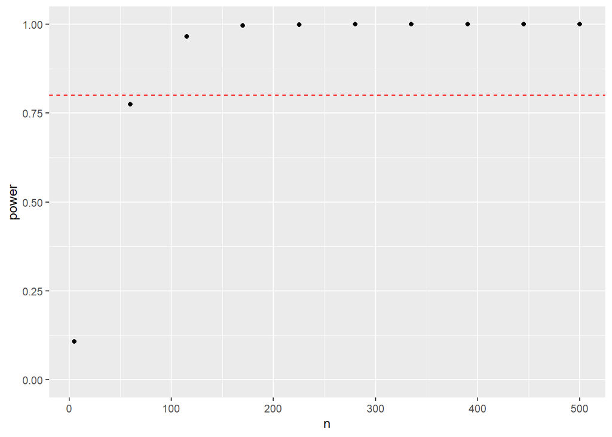

```r
ggplot(data = result_table_mean, aes(x = n, y = power)) +
  geom_point() +
  scale_x_continuous(limits = c(5, 500)) +
  scale_y_continuous(limits = c(0, 1)) +
  geom_hline(yintercept = 0.8, linetype = "dashed", color = "red")
```